# M2

Rafli Radithya

6/9/2023

# TUGAS PRAKTIKUM MPDW-REGRESI TIME SERIES

## Tentang Data

Data yang digunakan merupakan data m4 competition forecasting yang diperoleh dari website Kaggle dengan banyak datanya 4227 baris. Adapun daftar peubahnya terdiri dari

1. V2 = y
2. V3 = x1
3. V4 = x2
4. V5 = x3

Dalam tugas ini, digunakan 4 peubah tersebut dengan 1 sebagai peubah dependen, yaitu V2 dan V3, V4, dan V5 sebagai peubah independen

## Eksplorasi Data

1. Persiapan package

   ```r
   library(dplyr)
   library(TTR)
   library(forecast)
   library(lmtest) #digunakan untuk uji formal pendeteksian autokorelasi
   library(orcutt) #untuk membuat model regresi Cochrane-Orcutt
   library(HoRM) #untuk membuat model regresi Hildreth-Lu
   ```

2. Input data

   ```r
   setwd("C:/Users/USER/OneDrive/Dokumen/PRAKTIKUM MPDW 2023/PRAKTIKUM MPDW 2023/pertemuan2/data")
   mpdw=read.csv("mpdw2v2.csv",sep=";")
   mpdw
   ```

   ```
   ##              V2         V3         V4         V5
   ## 1     2039.2000  2035.0000  2051.8000  2061.8000
   ## 2     2986.0000  3001.2000  2975.9000  2996.1000
   ## 3     1120.7000  1117.9000  1115.1000  1112.3000
   ## 4     1190.0000  1162.0000  1134.0000  1106.0000
   ## 5     5904.6700  5917.0500  5922.5800  5928.8000
   ## 6     3182.0525  3147.0985  3143.8503  3128.2005
   ## 7     5860.0080  7773.2460  9477.8720  8209.0990
   ## 8     1732.2000  1731.8300  1739.1700  1741.8000
   ## 9     1584.4100  1584.0600  1590.7700  1592.6500
   ## 10    2618.0000  2638.6000  2648.7000  2656.2000
   ## 11    2440.2000  2439.7000  2469.3000  2434.4000
   ## 12    3663.3000  3670.6000  3704.1000  3695.2000
   ## 13    7208.4000  7262.7000  7251.2000  7320.4000
   ## 14    5762.9000  5721.8000  5789.5000  5756.0000
   ```

   [output cut: 4213 more lines]

3. Plot time series untuk setiap peubah

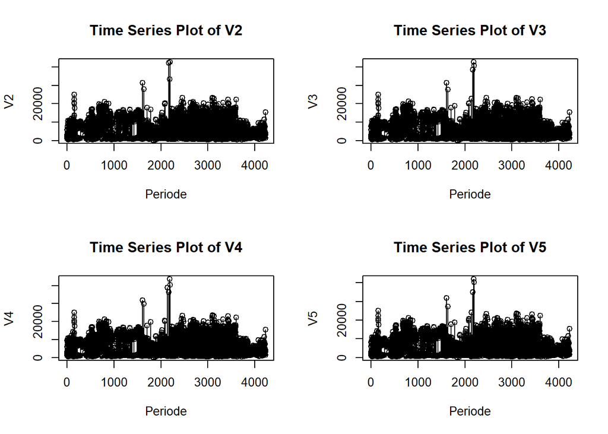

   ```r
   par(mfrow = c(2,2))
   #Temp
   v2.ts=ts(mpdw$V2)
   ts.plot(v2.ts, xlab="Periode", ylab="V2", main= "Time Series Plot of V2")
   points(v2.ts)

   #Humid
   v3.ts=ts(mpdw$V3)
   ts.plot(v3.ts, xlab="Periode", ylab="V3", main= "Time Series Plot of V3")
   points(v3.ts)

   #Solar
   v4.ts=ts(mpdw$V4)
   ts.plot(v4.ts, xlab="Periode", ylab="V4", main= "Time Series Plot of V4")
   points(v4.ts)

   #Wind
   v5.ts=ts(mpdw$V5)
   ts.plot(v5.ts, xlab="Periode", ylab="V5", main= "Time Series Plot of V5")
   points(v5.ts)
   ```

Berdasarkan eksplorasi plot time series di atas, diketahui bahwa 4 peubah, yaitu V2,V3,V4, dan V5 memiliki pola data time series yang relatif sama, yaitu sensasional additive. Adapun ciri khas dari pola tersebut, yaitu data berfluktuasi dengan ragam yang konstan

## Regresi Time Series

Pemodelan awal

```r
model=lm(V2~V3+V4+V5,data=mpdw)
summary(model)
```

```
##
## Call:
## lm(formula = V2 ~ V3 + V4 + V5, data = mpdw)
##
## Residuals:
##     Min      1Q  Median      3Q     Max
## -8227.3   -32.0    -7.9    27.8  2777.0
##
## Coefficients:
##             Estimate Std. Error t value Pr(>|t|)
## (Intercept) 16.35270    4.32120   3.784 0.000156 ***
## V3           1.52889    0.01923  79.492  < 2e-16 ***
## V4          -0.82460    0.01125 -73.267  < 2e-16 ***
## V5           0.29243    0.02068  14.143  < 2e-16 ***
## ---
## Signif. codes:  0 '***' 0.001 '**' 0.01 '*' 0.05 '.' 0.1 ' ' 1
##
## Residual standard error: 179.4 on 4223 degrees of freedom
## Multiple R-squared:  0.9989, Adjusted R-squared:  0.9989
## F-statistic: 1.242e+06 on 3 and 4223 DF,  p-value: < 2.2e-16
```

## Diagnostik Regresi

Terdapat beberapa asumsi regresi linear gauss-markov yang harus dipenuhi, yaitu

- Sisaan harus menyebar normal
- Nilai harapan sisaan = 0 dengan ragam yang konstan
- Tidak ada autokorelasi antar sisaan
- Tidak ada multikolinearitas

Dengan demikian, akan dilakukan diagnostik model awal yang telah didapat

1. Plot Eksplorasi

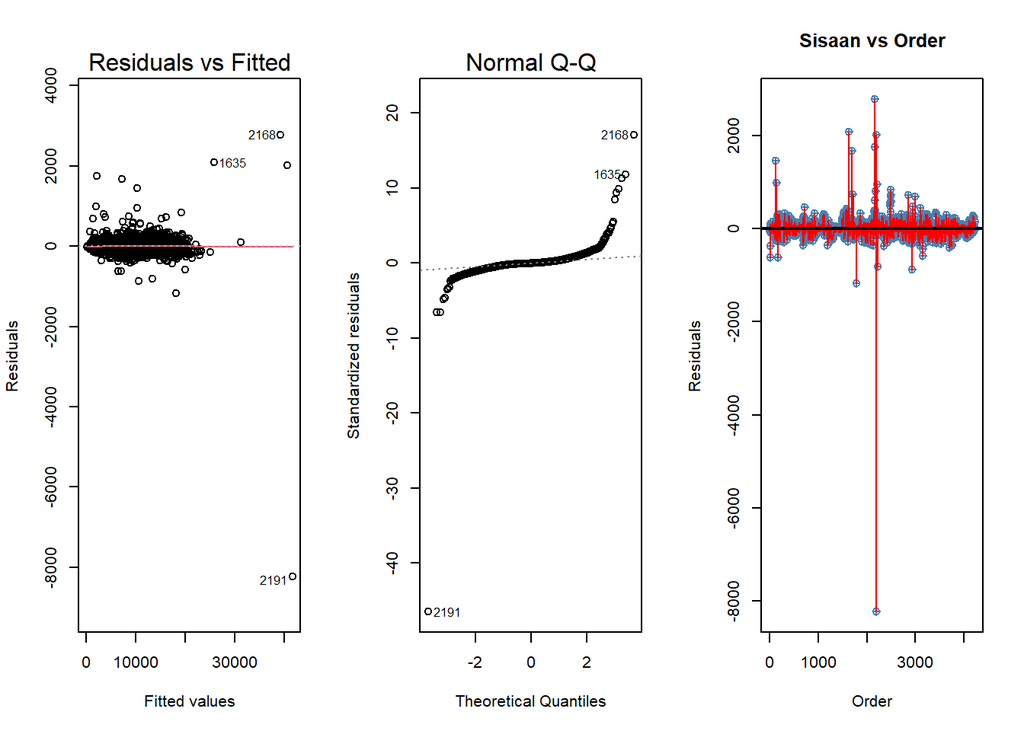

   ```r
   par(mfrow = c(1,3))
   #Plot residual vs fitted value
   plot(model,1)

   #Plot normal Q-Q plot
   plot(model,2)

   #Plot residual vs order
   sisaan<- residuals(model)
   plot(seq(1,4227,1), sisaan, col = "steelblue", pch = 10, xlab = "Order", ylab = "Residuals", main = "Sisaan vs Order")
   lines(seq(1,4227,1), sisaan, col = "red")
   abline(a = 0, b = 0, lwd = 2)
   ```

   Pada plot 3: Sisaan vs order, sisaan cenderung membentuk suatu pola yang stasioner sehingga dapat diduga kuat bahwa data mengandung autokorelasi.
2. Pengecekan multikolinearitas

   ```r
   #Pengecekan multikol dengan VIF
   library(car)
   vif(model)
   ```

   ```
   ##        V3        V4        V5
   ## 1394.8114  483.8389 1623.8500
   ```

   Berdasarkan pengujian multikolinearitas dengan metode VIF, diketahui bahwa terdapat multikolinearitas pada setiap variabel, yaitu pada V3, V4, dan V5. Hal tersebut ditandai dengan nilai VIF > 5
3. Plot ACF & PACF untuk autokorelasi

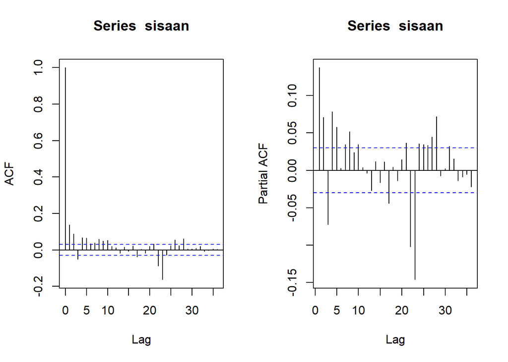

   ```r
   #Plot ACF dan PACF identifikasi autokorelasi
   par(mfrow = c(1,2))
   acf(sisaan)
   pacf(sisaan)
   ```

   Berdasarkan plot ACF dan partial ACF, diketahui bahwa terdapat beberapa amatan yang berada di luar selang sehingga dapat dicurigai terdapat autokorelasi dalam data tersebut.
4. Uji formal

   Akan dilakukan beberapa uji formal untuk mengecek asumsi, yaitu

   Kenormalan sisaan

   H0 : Sisaan menyebar normal vs H1 : Sisaan tidak menyebar normal

```r
#Uji Kolmogorov-Smirnov
ks.test(sisaan, "pnorm", mean=mean(sisaan), sd=sd(sisaan))
```

```
##
##  One-sample Kolmogorov-Smirnov test
##
## data:  sisaan
## D = 0.21586, p-value < 2.2e-16
## alternative hypothesis: two-sided
```

Berdasarkan hasil uji kenormalan sisaan dengan uji Kolmogorov-Smirnov, p-value yang < alpha 5% yang berarti bahwa sisaan tidak menyebar normal sehingga perlu dilakukan penanganan

Kehomogenan Ragam

H0 : Ragam homogen vs H1 : Ragam tidak homogen

```r
#Breusc-Pagan Test
library(lmtest)
bptest(model)
```

```
##
##  studentized Breusch-Pagan test
##
## data:  model
## BP = 213.32, df = 3, p-value < 2.2e-16
```

Berdasarkan uji kehomogenan ragam, diperoleh nilai p < taraf alpha 5% sehingga ragam sisaan tidak homogen

Autokorelasi

H0 : Tidak ada autokorelasi vs H1: Ada autokorelasi

```r
#Durbin Watson test
dwtest(model)
```

```
##
##  Durbin-Watson test
##
## data:  model
## DW = 1.7255, p-value < 2.2e-16
## alternative hypothesis: true autocorrelation is greater than 0
```

Berdasarkan uji autukorelasi dengan durbin-watson test, didapati p-value < taraf alpha 5% yang berarti terdapat autokorelasi antar sisaan dengan tingkat keyakinan 95%.

## Penanganan Autokorelasi

1. Metode Cochrane-Orcutt

   ```r
   #Penanganan Autokorelasi Cochrane-Orcutt
   modelCO<-cochrane.orcutt(model)
   modelCO
   ```

   ```
   ## Cochrane-orcutt estimation for first order autocorrelation
   ##
   ## Call:
   ## lm(formula = V2 ~ V3 + V4 + V5, data = mpdw)
   ##
   ##  number of interaction: 4
   ##  rho 0.139214
   ##
   ## Durbin-Watson statistic
   ## (original):    1.72554 , p-value: 2.031e-19
   ## (transformed): 2.01944 , p-value: 7.351e-01
   ##
   ##  coefficients:
   ## (Intercept)          V3          V4          V5
   ##   17.166026    1.515539   -0.832688    0.313705
   ```

   ```r
   #Rho optimum
   rho<- modelCO$rho

   #Transformasi Manual
   v2.trans<- mpdw$V2[-1]-mpdw$V2[-4227]*rho
   v3.trans<- mpdw$V3[-1]-mpdw$V3[-4227]*rho
   v4.trans<- mpdw$V4[-1]-mpdw$V4[-4227]*rho
   v5.trans<- mpdw$V5[-1]-mpdw$V5[-4227]*rho
   modelCOmanual<- lm(v2.trans~v3.trans+v4.trans+v5.trans)
   summary(modelCOmanual)
   ```

   ```
   ##
   ## Call:
   ## lm(formula = v2.trans ~ v3.trans + v4.trans + v5.trans)
   ##
   ## Residuals:
   ##     Min      1Q  Median      3Q     Max
   ## -8194.4   -32.6    -7.5    28.6  2760.7
   ##
   ## Coefficients:
   ##             Estimate Std. Error t value Pr(>|t|)
   ## (Intercept) 14.77627    4.05662   3.643 0.000273 ***
   ## v3.trans     1.51554    0.01938  78.186  < 2e-16 ***
   ## v4.trans    -0.83269    0.01109 -75.112  < 2e-16 ***
   ## v5.trans     0.31370    0.02092  14.994  < 2e-16 ***
   ## ---
   ## Signif. codes:  0 '***' 0.001 '**' 0.01 '*' 0.05 '.' 0.1 ' ' 1
   ##
   ## Residual standard error: 177.7 on 4222 degrees of freedom
   ## Multiple R-squared:  0.9988, Adjusted R-squared:  0.9988
   ## F-statistic: 1.133e+06 on 3 and 4222 DF,  p-value: < 2.2e-16
   ```

   ```r
   #Mencari Penduga Koefisien Regresi setelah Transformasi ke Persamaan Awal
   b0bintang <- modelCOmanual$coefficients[1]
   b0 <- b0bintang/(1-rho)
   b1 <- modelCOmanual$coefficients[2]
   b2 <- modelCOmanual$coefficients[3]
   b3 <- modelCOmanual$coefficients[4]
   data.frame(b0,b1,b2,b3)
   ```

   ```
   ##                   b0       b1         b2        b3
   ## (Intercept) 17.16603 1.515539 -0.8326881 0.3137049
   ```

   Setelah dilakukan transformasi kembali, didapati model seperti model yang dihasilkan menggunakan package, yaitu **y=17.16603+1.515539x1-0.8326881+0.3137049x3**. Selanjutnya, akan diuji autokorelasi dari model tersebut dengan uji durbin-watson

   H0 : tidak ada autokorelasi vs H1 : ada autokorelasi

   ```r
   dwtest(modelCOmanual)
   ```

   ```
   ##
   ##  Durbin-Watson test
   ##
   ## data:  modelCOmanual
   ## DW = 2.0194, p-value = 0.7351
   ## alternative hypothesis: true autocorrelation is greater than 0
   ```

   Berdasarkan pengujian menggunakan durbin watson tst, diketahui bahwa nilai p-value yang didapatkan sebesar 0.7351 yang > alpha (0.05) sehingga belum cukup bukti untuk menyatakan ada autokorelasi dalam model tersebut. Oleh karena itu, penanganan autokorelasi dengan metode Cochrane-Orcutt tertangani
2. Metode Hildreth-Lu

   ```r
   #Penanganan Autokorelasi Hildreth lu
   #Pembuatan Hildreth-Lu Function

   hildreth.lu.func<- function(r, model){
     x <- model.matrix(model)[,-1]
     y <- model.response(model.frame(model))
     n <- length(y)
     t <- 2:n
     y <- y[t]-r*y[t-1]
     x <- x[t]-r*x[t-1]

     return(lm(y~x))
   }
   ```

Akan dicari rho yang meminimumkan SSE dengan syntax berikut

[output not shown]

Untuk mencari nilai rho yang lebih optimum, akan dilakukan pengecilan selang dan jarak antar rho. Pada proses sebelumnya, diketahui nilai rho optimum berada pada 0.1 sehingga akan dipilih rentang rho yang lebih kecil, 0.001 sampai 0.2 dengan jarak tiap nilai rho 0.001

[output not shown]

Uji DW TEST

Untuk melihat keberhasilan penanganan autokorelasi dengan metode Hildreth-lu, dilakukan pengujian autokorelasi kembali menggunakan durbin watson test dengan syntax berikut

H0 : Tidak ada autokorelasi vs H1 : Ada autokorelasi

```r
dwtest(modelHL)
```

```
##
##  Durbin-Watson test
##
## data:  modelHL
## DW = 1.9264, p-value = 0.008228
## alternative hypothesis: true autocorrelation is greater than 0
```

## Keakuratan Metode Cochrane-Orcutt

Keakuratan Cochrane-Orcutt akan diukur berdasarkan perbandingan nilai Mean Square Error dan Sum Square Error dengan model awal

```r
#Model Awal
sseModelawal <- anova(model)$`Sum Sq`[-1]
mseModelawal <- sseModelawal/4227

#Model Cochrane-Orcutt
sseModelCO <- anova(modelCOmanual)$`Sum Sq`[-1]
mseModelCO <- sseModelCO/4227

#Perbandingan
akurasi <- matrix(c(sseModelawal,sseModelCO,
                    mseModelawal,mseModelCO),nrow=2,ncol=2,byrow = T)

colnames(akurasi) <- c("Model Awal","Model Cochrane-Orcutt")
row.names(akurasi) <- c("SSE","MSE")
akurasi
```

```
##     Model Awal Model Cochrane-Orcutt
## SSE  175407849               6440637
## MSE  135977622             180104366
```

## Kesimpulan

Pada model regresi data m4 competition forecasting dengan peubah V2,V3,V4, dan V5, data masih mengandung nilai autokorelasi sehingga ditangani dengan metode Cochrane-Orcutt dan Hildreth-lu. Autokorelasi model berhasil tertangani dengan metode Cochrane-Orcutt dengan model akhir, yaitu y=17.16603+1.515539x1-0.8326881x2+0.3137049x3